# TechCorp Hiring Analysis Report

Justin Hughes

10/27/2024

# Introduction

TechCorp, a global technological leader, is facing growing competition for quality talent in an evolving tech industry. To bolster its hiring strategies, TechCorp has initiated a study to understand how candidates’ educational backgrounds influence their performance on technical tests and hiring outcomes. This analysis aims to determine if higher education consistently leads to better outcomes and to identify any diminishing returns beyond a bachelor’s degree.

## Study & Data Summary

This study uses historical hiring data from TechCorp, capturing a wide range of metrics. The dataset offers insights into both technical and non-technical aspects of the hiring process, such as education levels, technical test scores, interview performance, and hiring outcomes. By understanding these relationships, TechCorp can enhance its talent acquisition strategy to remain competitive.

We will explore three key questions:

- **How does education level affect technical test performance?** Preliminary observations suggest a correlation between higher education and improved performance, but we need to determine if this holds true across all education levels.
- **What is the impact of technical test scores on hiring success?** Technical test performance is expected to play a significant role in hiring outcomes.
- **Does education level moderate the relationship between technical performance and hiring success?** We aim to see if higher degrees compensate for lower technical scores.

## Report Outline

This report is structured as follows:

1. **Data and Exploratory Analysis**: Details about the dataset, methodologies used, analysis performed, and results.
2. **Conclusion and Discussion**: A review of the key findings, additional observations, and potential future directions.
3. **Appendix**: Tables, plots, and R code.

# Data and Exploratory Analysis

## Data Summary

The study uses three datasets from TechCorp’s hiring processes, covering demographic information, technical skills, and interview performance. The data were merged into a single dataset for ease of analysis, containing:

- **Demographics**: Age, gender, education level, elite college status.
- **Performance Metrics**: Technical scores in Python, SQL, Machine Learning, interview ratings, cultural fit.
- **Outcomes**: Whether the candidate was hired, the position applied for, and work environment preferences.

The data was sourced internally from TechCorp and reflects a mix of technical and non-technical attributes critical to the hiring process.

## Summary Statistics

### Summary 1: Tabyl Summary

|  | Education Level | No | Yes |
| --- | --- | --- | --- |
| 1 | Bachelor's | 92.3% | 7.7% |
| 2 | High School | 92.8% | 7.2% |
| 3 | Master's | 92.8% | 7.2% |
| 4 | PhD | 94.0% | 6.0% |
| 5 | Total | 371.9% | 28.1% |

### Summary 2: Grouped Summary by Education Level

| Education Level | mean_score | median_score | sd_score |
| --- | --- | --- | --- |
| Bachelor's | 5.536313 | 6 | 2.875603 |
| High School | 5.524260 | 5 | 2.831097 |
| Master's | 5.526674 | 6 | 2.876556 |
| PhD | 5.325370 | 5 | 2.816512 |

### Summary 3: Grouped Summary by Hiring Outcome

| Hired | mean_score | median_score | count |
| --- | --- | --- | --- |
| No | 5.229871 | 5 | 3254 |
| Yes | 8.760163 | 9 | 246 |

# Question 1: Effect of Education Level on Technical Test Performance

### Data

The dataset includes candidate demographics and their technical test scores in domains such as Python, SQL, and Machine Learning.

### Method

Descriptive statistics were calculated to summarize technical test scores by education level, and visualized using a box plot.

### Analysis

The summary statistics and the box plot help assess whether higher education correlates with better technical test scores.

### Results

On average, candidates with bachelor’s and master’s degrees show similar performance, with a slight drop observed for PhD holders, suggesting possible diminishing returns.

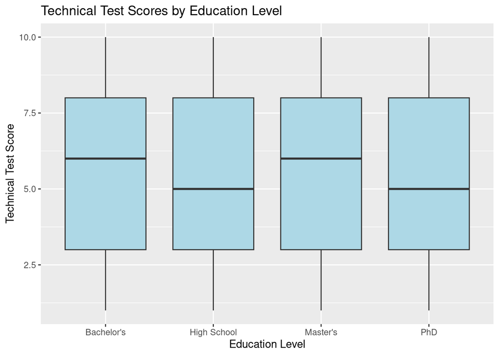

# Question 2: Impact of Technical Test Scores on Hiring Success

### Data

Technical test scores and hiring outcomes were used to explore the relationship between candidate performance and hiring success.

### Method

Summary statistics were calculated, and a histogram was used to visualize the distribution of technical scores by hiring outcome.

### Analysis

A significant difference was observed in the average scores of hired vs. non-hired candidates, indicating a strong influence of technical test performance on hiring decisions.

### Results

The mean technical test score for hired candidates is significantly higher than for non-hired candidates.

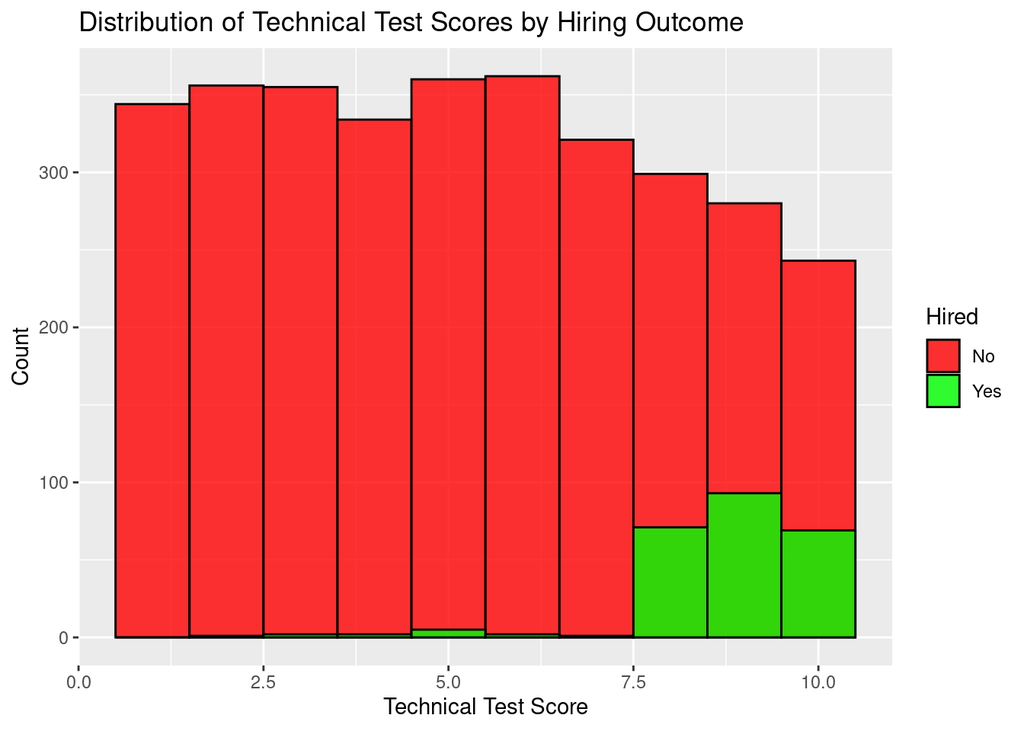

# Question 3: Moderation Effect of Education Level

### Data

Candidate education levels, technical test scores, and hiring outcomes were considered to assess potential moderation effects.

### Results

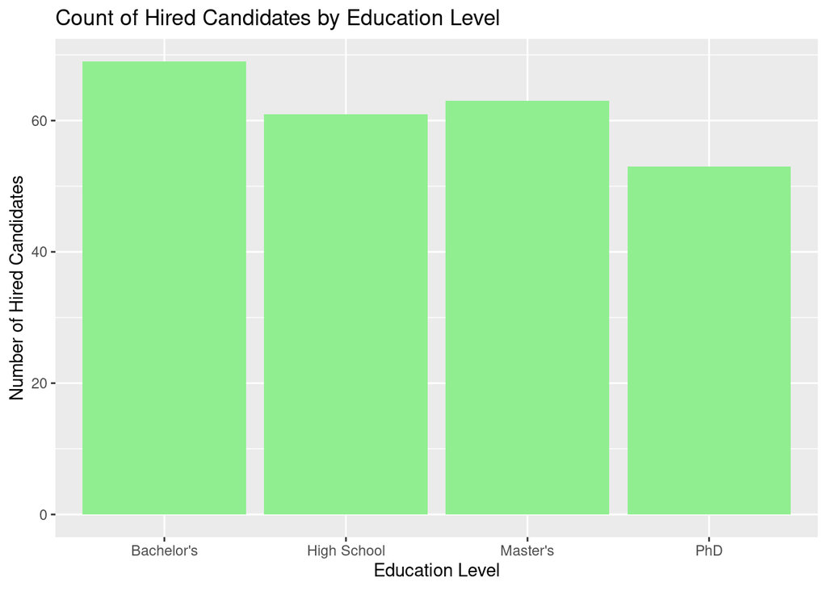

# Conclusion and Discussion

## Additional Observations

- **Education Level and Hiring Outcome**: There is evidence suggesting that a bachelor’s degree may be sufficient for optimal performance, with diminishing returns for further education.
- **Technical vs. Non-Technical Skills**: Non-technical evaluations, such as cultural fit, may play a compensatory role in the hiring process.

## Future Directions

- **Biases in Hiring**: Further analysis should explore potential biases related to educational background, gender, or other demographic factors.
- **Skill-Specific Analysis**: Future studies could examine how specific skills (e.g., Python, SQL) directly impact hiring success.
- **Longitudinal Studies**: Tracking employee performance post-hiring could provide insights into the long-term value of education and technical skills.

## Recommendations

- Focus on technical skills as a primary hiring criterion, especially for candidates with higher education.
- Consider revising hiring criteria to avoid overvaluing degrees beyond the bachelor’s level.
- Improve the assessment of non-technical skills to better identify candidates with potential for long-term success.

# Appendix

## Data Preperation

```r
library(tidyverse)
library(janitor)

interview_data <- read_csv("Datasets/CandidateInterviewandHiring.csv")
personal_data <- read_csv("Datasets/CandidatePersonalData.csv")
technical_scores <- read_csv("Datasets/CandidateTechicalScores.csv")

merged_data <- personal_data %>%
  inner_join(technical_scores, by = "Candidate-ID") %>%
  inner_join(interview_data, by = "Candidate-ID")
```

## Detailed Tables

### Tabyl Summary Table

```r
merged_data %>%
  tabyl(`Education Level`, `Hired`) %>%
  adorn_percentages("row") %>%
  adorn_totals("row") %>%
  adorn_pct_formatting(digits = 1)
```

|  | Education Level | No | Yes |
| --- | --- | --- | --- |
| 1 | Bachelor's | 92.3% | 7.7% |
| 2 | High School | 92.8% | 7.2% |
| 3 | Master's | 92.8% | 7.2% |
| 4 | PhD | 94.0% | 6.0% |
| 5 | Total | 371.9% | 28.1% |

### Summary Statistics by Education Level

```r
merged_data %>%
  group_by(`Education Level`) %>%
  summarise(mean_score = mean(`Technical Test Score`, na.rm = TRUE),
            median_score = median(`Technical Test Score`, na.rm = TRUE),
            sd_score = sd(`Technical Test Score`, na.rm = TRUE))
```

| Education Level | mean_score | median_score | sd_score |
| --- | --- | --- | --- |
| Bachelor's | 5.536313 | 6 | 2.875603 |
| High School | 5.524260 | 5 | 2.831097 |
| Master's | 5.526674 | 6 | 2.876556 |
| PhD | 5.325370 | 5 | 2.816512 |

### Grouped Summary by Hiring Outcome

```r
merged_data %>%
  group_by(`Hired`) %>%
  summarise(mean_score = mean(`Technical Test Score`, na.rm = TRUE),
            median_score = median(`Technical Test Score`, na.rm = TRUE),
            count = n())
```

| Hired | mean_score | median_score | count |
| --- | --- | --- | --- |
| No | 5.229871 | 5 | 3254 |
| Yes | 8.760163 | 9 | 246 |

## Plots

### Box Plot of Technical Test Scores by Education Level

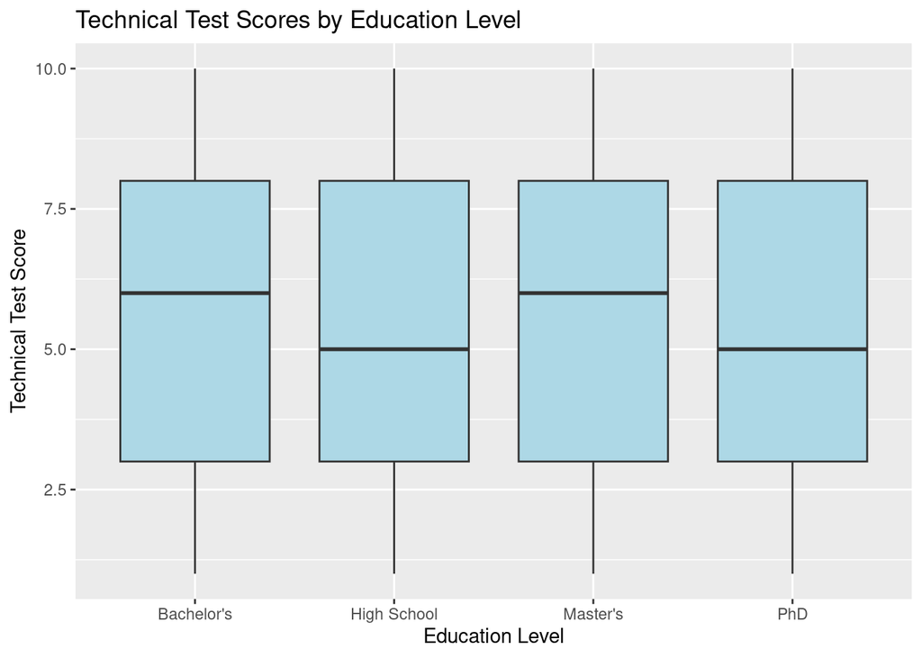

```r
ggplot(merged_data, aes(x = `Education Level`, y = `Technical Test Score`)) +
  geom_boxplot(fill = "lightblue") +
  labs(title = "Technical Test Scores by Education Level", x = "Education Level", y = "Technical Test Score")
```

### Histogram of Technical Test Scores by Hiring Outcome

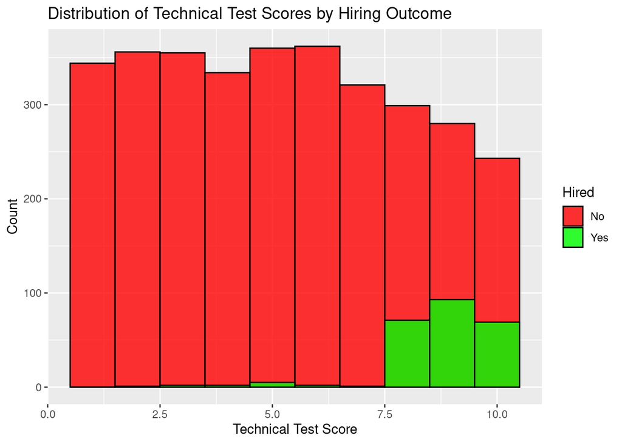

```r
ggplot(merged_data, aes(x = `Technical Test Score`, fill = `Hired`)) +
  geom_histogram(color = "black", binwidth = 1, position = "identity", alpha = 0.8) +
  scale_fill_manual(values = c("No" = "red", "Yes" = "green")) +
  labs(title = "Distribution of Technical Test Scores by Hiring Outcome", x = "Technical Test Score", y = "Count")
```

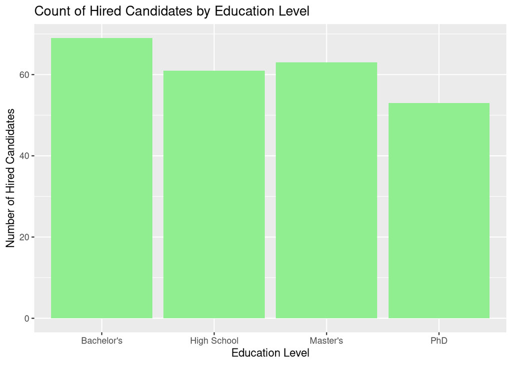

```r
merged_data %>%
  filter(Hired == "Yes") %>%
  ggplot(aes(x = `Education Level`)) +
  geom_bar(fill = "lightgreen") +
  labs(title = "Count of Hired Candidates by Education Level", x = "Education Level", y = "Number of Hired Candidates")
```

## R Commands

- `library()`: Loads packages used for data analysis.
- `tabyl(variable1, variable2)`: Generates a cross-tabulation of two variables, providing counts for each combination, used to summarize the relationship between education level and hiring.
- `group_by(column_name)`: Groups the data frame by the specified column, allowing subsequent operations (e.g., summarise) to be performed on each group separately.
- `summarise(mean_score = mean(column, na.rm = TRUE))`: Calculates summary statistics for each group, such as the mean, median, and standard deviation of a column, while ignoring missing values.
- `ggplot(data, aes(x, y)) + geom_boxplot()`: Creates a box plot visualization for comparing technical test scores by education level.
- `geom_histogram(binwidth = value)`: Creates a histogram to visualize the distribution of technical test scores, with different colors indicating whether a candidate was hired or not.
- `geom_bar()`: Creates a bar plot to visualize the count of hired candidates by education level.